# Final Project — Domain-Appropriate Models for Building Energy Classification

Group 5

2026-06-11

```r
pkgs <- c(
  "tidyverse", "caret", "readxl", "ggplot2", "dplyr",
  "ordinalForest",  # Ordinal Random Forest
  "naivebayes",     # Naive Bayes with Gaussian distributions
  "pROC",           # Multiclass AUC
  "knitr"           # Table formatting
)

lapply(pkgs, library, character.only = TRUE)
```

[output not shown]

[output cut: 45 more lines]

```r
img_dir <- "/home/jakes/Documents/strathmore/Modules/Module 3/linear_models/classwork/final_project/markdowns/images/domainClassification"
dir.create(img_dir, showWarnings = FALSE, recursive = TRUE)
```

# 1 Why These Models?

The classification file in the main nonlinear analysis assigned each building to one of three energy load classes — Low, Medium, or High — and evaluated models on accuracy and AUC. Those are reasonable general metrics, but they treat all misclassifications as equally bad. In reality, predicting “High” when the true class is “Low” is a much more serious mistake than predicting “Medium” when the true class is “Low”. A building engineer or policy maker relying on the model would make very different decisions in each case.

# 2 Load Data

```r
df <- read_excel(
  "~/Documents/strathmore/Modules/Module 3/linear_models/classwork/final_project/markdowns/new_data/ENB2012_post_EDA.xlsx"
)

cat("Rows:", nrow(df), "\n")
```

```
## Rows: 768
```

```r
cat("Columns:", paste(names(df), collapse = ", "), "\n")
```

```
## Columns: RelCompactness, SurfaceArea, WallArea, RoofArea, OverallHeight, Orientation, GlazingArea, GlazingAreaDist, HeatingLoad, CoolingLoad, Orientation_f, OverallHeight_f, GlazingArea_f, GlazingAreaDist_f, is_outlier
```

# 3 Restore Factor Variables

```r
df$Orientation_f <- factor(df$Orientation, levels = 2:5,
                            labels = c("N", "E", "S", "W"))

df$OverallHeight_f <- factor(df$OverallHeight, levels = c(3.5, 7.0),
                              labels = c("Low_3.5m", "High_7m"))

df$GlazingArea_f <- factor(df$GlazingArea, levels = c(0, 0.1, 0.25, 0.4),
                            labels = c("None", "Low_10pct", "Med_25pct",
                                       "High_40pct"))

df$GlazingAreaDist_f <- factor(df$GlazingAreaDist, levels = 0:5,
                                labels = c("None", "Uniform", "N_heavy",
                                           "E_heavy", "S_heavy", "W_heavy"))

cat("Factor levels confirmed.\n")
```

```
## Factor levels confirmed.
```

# 4 Feature Engineering

We reproduce the same physically motivated engineered features used throughout the project. These are all products, ratios, or squares of the original building geometry variables that correspond to quantities that appear in heat transfer calculations. None use the target variable, so building them before the train/test split is safe.

```r
df_clean <- df %>%
  mutate(
    CompactnessXHeight  = RelCompactness * OverallHeight,
    WallToRoofRatio     = WallArea / RoofArea,
    GlazingXCompactness = GlazingArea * RelCompactness,
    SurfToVol           = SurfaceArea / (WallArea + RoofArea),
    GlazingXHeight      = GlazingArea * OverallHeight,
    WallXGlazing        = WallArea * GlazingArea,
    CompactnessSquared  = RelCompactness^2,
    HeightSquared       = OverallHeight^2,
    GlazingToWall       = GlazingArea / (WallArea + 1),
    EnvelopeArea        = WallArea + RoofArea,
    WallPerHeight       = WallArea / (OverallHeight + 1)
  )

cat("Feature engineering complete. Total columns:", ncol(df_clean), "\n")
```

```
## Feature engineering complete. Total columns: 26
```

# 5 Constructing the Classification Target

The classification target is built by splitting HeatingLoad and CoolingLoad into three equal-sized groups using tertile boundaries. Each building is labelled Low, Medium, or High based on which third of the load distribution it falls into.

It is worth noting that the tertile boundaries for this dataset land very close to the EU Energy Performance of Buildings Directive thresholds for residential heating:

- The Low/Medium boundary falls at approximately 14.5 kWh/m², which is almost exactly the EU’s Class A/B threshold of 15 kWh/m².
- The Medium/High boundary falls at approximately 28.6 kWh/m², close to the EU’s Class B/C threshold of 30 kWh/m².

This near-alignment is not a coincidence — EnergyPlus was designed to simulate realistic building performance ranges, and those ranges naturally span the same territory that energy standards were written to cover. It means our three classes are not arbitrary statistical buckets; they have a genuine physical and regulatory interpretation. This is precisely what makes the standards-based classifier a meaningful comparison rather than a trivial one.

```r
# Tertile boundaries computed from the full dataset before splitting
hl_breaks <- quantile(df_clean$HeatingLoad, probs = c(0, 1/3, 2/3, 1))
cl_breaks <- quantile(df_clean$CoolingLoad, probs = c(0, 1/3, 2/3, 1))

df_clean <- df_clean %>%
  mutate(
    HL_class = cut(HeatingLoad,
                   breaks         = hl_breaks,
                   labels         = c("Low", "Medium", "High"),
                   include.lowest = TRUE),
    CL_class = cut(CoolingLoad,
                   breaks         = cl_breaks,
                   labels         = c("Low", "Medium", "High"),
                   include.lowest = TRUE),
    # Ordered factors — critical for the ordinal models
    HL_class_ord = factor(HL_class,
                          levels  = c("Low", "Medium", "High"),
                          ordered = TRUE),
    CL_class_ord = factor(CL_class,
                          levels  = c("Low", "Medium", "High"),
                          ordered = TRUE)
  )

cat("HeatingLoad tertile boundaries:\n")
```

```
## HeatingLoad tertile boundaries:
```

```r
cat(sprintf("  Low / Medium boundary : %.2f kWh/m²\n", hl_breaks[2]))
```

```
##   Low / Medium boundary : 14.54 kWh/m²
```

```r
cat(sprintf("  Medium / High boundary: %.2f kWh/m²\n", hl_breaks[3]))
```

```
##   Medium / High boundary: 28.63 kWh/m²
```

```r
cat(sprintf("  (EU A/B threshold: 15 kWh/m²,  EU B/C threshold: 30 kWh/m²)\n\n"))
```

```
##   (EU A/B threshold: 15 kWh/m²,  EU B/C threshold: 30 kWh/m²)
```

```r
cat("Class distribution — Heating Load:\n")
```

```
## Class distribution — Heating Load:
```

```r
print(table(df_clean$HL_class))
```

```
##
##    Low Medium   High
##    257    255    256
```

```r
cat("\nClass distribution — Cooling Load:\n")
```

```
##
## Class distribution — Cooling Load:
```

```r
print(table(df_clean$CL_class))
```

```
##
##    Low Medium   High
##    257    255    256
```

# 6 Group Key and Train/Test Split

The same group-aware split used throughout the project. All four orientation variants of each building configuration go entirely to training or entirely to test, preventing the model from recognising a building it has already seen under a different compass direction.

```r
df_clean <- df_clean %>%
  mutate(
    group_key = paste(RelCompactness, WallArea, RoofArea,
                      OverallHeight, GlazingArea, GlazingAreaDist, sep = "_")
  )

set.seed(42)
unique_groups  <- unique(df_clean$group_key)
n_train_groups <- round(0.80 * length(unique_groups))
train_groups   <- sample(unique_groups, n_train_groups)

df_train <- df_clean %>% filter( group_key %in% train_groups)
df_test  <- df_clean %>% filter(!group_key %in% train_groups)

group_overlap <- length(intersect(df_train$group_key, df_test$group_key))
cat("Training rows :", nrow(df_train), "\n")
```

```
## Training rows : 616
```

```r
cat("Test rows     :", nrow(df_test),  "\n")
```

```
## Test rows     : 152
```

```r
cat("Group overlap :", group_overlap,
    ifelse(group_overlap == 0, "  <- zero leakage confirmed\n",
                               "  <- WARNING: leakage present\n"))
```

```
## Group overlap : 0   <- zero leakage confirmed
```

# 7 Feature Set and Scaling

SurfaceArea and Orientation are excluded for the same reasons established in the main nonlinear file. Scaling is fitted on training data only.

```r
features <- c(
  "RelCompactness", "WallArea", "RoofArea",
  "OverallHeight", "GlazingArea", "GlazingAreaDist",
  "CompactnessXHeight", "WallToRoofRatio", "GlazingXCompactness",
  "SurfToVol", "GlazingXHeight", "WallXGlazing",
  "CompactnessSquared", "GlazingToWall", "EnvelopeArea", "WallPerHeight"
)

scale_cols <- features

preproc_params <- caret::preProcess(
  df_train[, scale_cols],
  method = c("center", "scale")
)

df_train[, scale_cols] <- predict(preproc_params, df_train[, scale_cols])
df_test[, scale_cols]  <- predict(preproc_params, df_test[, scale_cols])

cat("Scaling complete. Fitted on training set only.\n")
```

```
## Scaling complete. Fitted on training set only.
```

```r
cat("Feature count:", length(features), "\n")
```

```
## Feature count: 16
```

# 8 Build Model Datasets

We assemble the training and test frames that each model will use. We need both the unordered factor version (for Naive Bayes and metric calculation) and the ordered factor version (for the Ordinal Random Forest).

```r
# Heating Load — unordered (for NB, metrics)
train_HL <- df_train[, c(features, "HL_class")]
test_HL  <- df_test[,  c(features, "HL_class")]

# Heating Load — ordered (for Ordinal Forest)
train_HL_ord <- df_train[, c(features, "HL_class_ord")]
test_HL_ord  <- df_test[,  c(features, "HL_class_ord")]

# Cooling Load — unordered
train_CL <- df_train[, c(features, "CL_class")]
test_CL  <- df_test[,  c(features, "CL_class")]

# Cooling Load — ordered
train_CL_ord <- df_train[, c(features, "CL_class_ord")]
test_CL_ord  <- df_test[,  c(features, "CL_class_ord")]

cat("Heating Load class distribution in training set:\n")
```

```
## Heating Load class distribution in training set:
```

```r
print(table(train_HL$HL_class))
```

```
##
##    Low Medium   High
##    189    210    217
```

```r
cat("\nCooling Load class distribution in training set:\n")
```

```
##
## Cooling Load class distribution in training set:
```

```r
print(table(train_CL$CL_class))
```

```
##
##    Low Medium   High
##    192    210    214
```

# 9 Evaluation Helpers

```r
# Standard classification metrics
eval_clf <- function(actual, predicted, model_name) {
  acc <- mean(actual == predicted)
  cm  <- table(Actual = actual, Predicted = predicted)
  cat(sprintf("%-35s  Accuracy = %.4f\n", model_name, acc))
  list(model_name = model_name, accuracy = acc, confusion = cm)
}

# Ranked Probability Score for ordinal predictions
# Takes a matrix of class probabilities (columns = Low, Medium, High in order)
ranked_prob_score <- function(prob_matrix, actual_ordered) {
  classes <- levels(actual_ordered)
  k <- length(classes)
  n <- length(actual_ordered)

  rps_vals <- sapply(seq_len(n), function(i) {
    true_class <- which(classes == as.character(actual_ordered[i]))
    obs_cdf    <- cumsum(c(rep(0, true_class - 1), 1, rep(0, k - true_class)))
    obs_cdf    <- obs_cdf[-k]   # cumulative indicators (length k-1)
    pred_cdf   <- cumsum(prob_matrix[i, ])[-k]
    mean((pred_cdf - obs_cdf)^2)
  })
  mean(rps_vals)
}

# Results accumulator
results_HL <- data.frame()
results_CL <- data.frame()
```

# 10 Model 1 — Standards-Based Classifier (Domain Baseline)

## 10.1 What it is and why it matters

Before training any model, it is worth asking what a domain expert would do without machine learning. A building energy consultant classifying buildings by heating load would not run a Random Forest — they would apply the thresholds from the energy performance standard that governs their work.

The EU Energy Performance of Buildings Directive assigns residential buildings to energy classes based on their annual heating demand in kWh per square metre. The boundaries most directly relevant to our dataset’s load range are:

- **Class A** (efficient): below 15 kWh/m²
- **Class B** (good): 15 – 30 kWh/m²
- **Class C and above** (less efficient): above 30 kWh/m²

We map these to our Low/Medium/High labels and apply them directly to the test set without any training step whatsoever. This classifier has seen zero training data — its rules come entirely from the regulatory standard.

The gap between this classifier’s accuracy and the accuracy of the learned models is the empirical value that machine learning adds over domain expertise alone. If the gap is large, the learned model is capturing something the standard misses. If the gap is small, the physical rules encoded in the standard are already nearly sufficient.

## 10.2 Y1 — Heating Load

```r
# EU Standards-Based Classifier — Heating Load
# The raw HeatingLoad is on the test buildings BEFORE the class labels were
# applied. We apply the EU thresholds to the raw HeatingLoad column.
# Note: df_test still has HeatingLoad (unscaled — scaling was only applied
# to the feature columns, not to the target).

standards_pred_HL <- case_when(
  df_test$HeatingLoad < 15 ~ "Low",
  df_test$HeatingLoad < 30 ~ "Medium",
  TRUE                     ~ "High"
) %>% factor(levels = c("Low", "Medium", "High"))

cat("=== STANDARDS-BASED CLASSIFIER — Heating Load ===\n")
```

```
## === STANDARDS-BASED CLASSIFIER — Heating Load ===
```

```r
cat("EU thresholds: Low < 15 kWh/m², 15 ≤ Medium < 30 kWh/m², High ≥ 30 kWh/m²\n\n")
```

```
## EU thresholds: Low < 15 kWh/m², 15 ≤ Medium < 30 kWh/m², High ≥ 30 kWh/m²
```

```r
std_HL_result <- eval_clf(test_HL$HL_class, standards_pred_HL,
                           "Standards-Based (EU)")
```

```
## Standards-Based (EU)                 Accuracy = 0.9342
```

```r
cat("\nConfusion matrix:\n")
```

```
##
## Confusion matrix:
```

```r
print(std_HL_result$confusion)
```

```
##         Predicted
## Actual   Low Medium High
##   Low     68      0    0
##   Medium   7     38    0
##   High     0      3   36
```

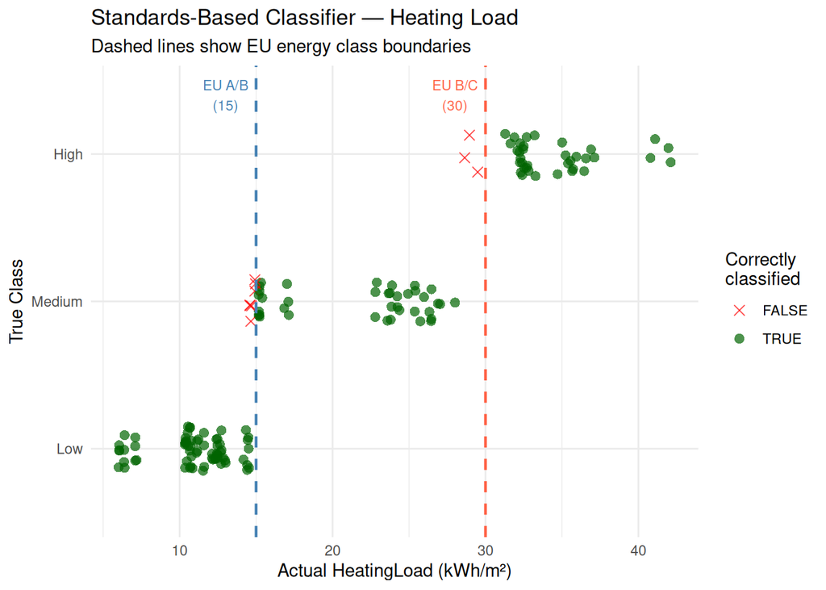

```r
results_HL <- rbind(results_HL,
  data.frame(Model    = "Standards-Based (EU)",
             Accuracy = std_HL_result$accuracy))

# Visualise where the EU thresholds agree and disagree with tertile labels
standards_HL_df <- data.frame(
  HeatingLoad     = df_test$HeatingLoad,
  True_Class      = test_HL$HL_class,
  Predicted_Class = standards_pred_HL,
  Correct         = (test_HL$HL_class == standards_pred_HL)
)

p_std_HL <- ggplot(standards_HL_df,
                   aes(x = HeatingLoad, y = True_Class,
                       colour = Correct, shape = Correct)) +
  geom_jitter(height = 0.15, alpha = 0.7, size = 2.5) +
  geom_vline(xintercept = 15, linetype = "dashed",
             colour = "steelblue", linewidth = 0.8) +
  geom_vline(xintercept = 30, linetype = "dashed",
             colour = "tomato", linewidth = 0.8) +
  scale_colour_manual(values = c("TRUE" = "darkgreen", "FALSE" = "red"),
                      name = "Correctly\nclassified") +
  scale_shape_manual(values  = c("TRUE" = 16, "FALSE" = 4),
                     name = "Correctly\nclassified") +
  annotate("text", x = 13, y = 3.4, label = "EU A/B\n(15)", size = 3,
           colour = "steelblue") +
  annotate("text", x = 28, y = 3.4, label = "EU B/C\n(30)", size = 3,
           colour = "tomato") +
  labs(title    = "Standards-Based Classifier — Heating Load",
       subtitle = "Dashed lines show EU energy class boundaries",
       x = "Actual HeatingLoad (kWh/m²)",
       y = "True Class") +
  theme_minimal()

ggsave(file.path(img_dir, "standards_hl_classification.png"),
       plot = p_std_HL, width = 9, height = 5, dpi = 150)
print(p_std_HL)
```

## 10.3 Y2 — Cooling Load

```r
# EU Standards-Based Classifier — Cooling Load
# EU cooling standards are less universally standardised than heating, but
# comparable thresholds are used in Mediterranean and mixed-climate frameworks.
# We apply the same 15/30 kWh/m² boundaries for consistency and comparability.

standards_pred_CL <- case_when(
  df_test$CoolingLoad < 15 ~ "Low",
  df_test$CoolingLoad < 30 ~ "Medium",
  TRUE                     ~ "High"
) %>% factor(levels = c("Low", "Medium", "High"))

cat("=== STANDARDS-BASED CLASSIFIER — Cooling Load ===\n\n")
```

```
## === STANDARDS-BASED CLASSIFIER — Cooling Load ===
```

```r
std_CL_result <- eval_clf(test_CL$CL_class, standards_pred_CL,
                           "Standards-Based (EU)")
```

```
## Standards-Based (EU)                 Accuracy = 0.8618
```

```r
cat("\nConfusion matrix:\n")
```

```
##
## Confusion matrix:
```

```r
print(std_CL_result$confusion)
```

```
##         Predicted
## Actual   Low Medium High
##   Low     44     21    0
##   Medium   0     45    0
##   High     0      0   42
```

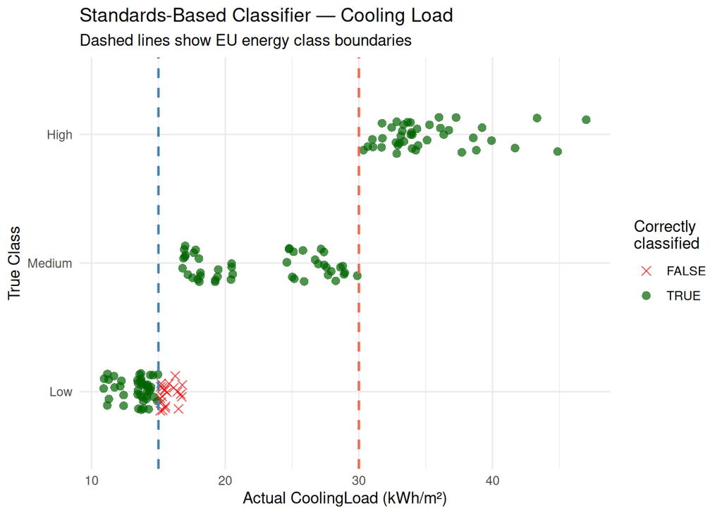

```r
results_CL <- rbind(results_CL,
  data.frame(Model    = "Standards-Based (EU)",
             Accuracy = std_CL_result$accuracy))

standards_CL_df <- data.frame(
  CoolingLoad     = df_test$CoolingLoad,
  True_Class      = test_CL$CL_class,
  Predicted_Class = standards_pred_CL,
  Correct         = (test_CL$CL_class == standards_pred_CL)
)

p_std_CL <- ggplot(standards_CL_df,
                   aes(x = CoolingLoad, y = True_Class,
                       colour = Correct, shape = Correct)) +
  geom_jitter(height = 0.15, alpha = 0.7, size = 2.5) +
  geom_vline(xintercept = 15, linetype = "dashed",
             colour = "steelblue", linewidth = 0.8) +
  geom_vline(xintercept = 30, linetype = "dashed",
             colour = "tomato", linewidth = 0.8) +
  scale_colour_manual(values = c("TRUE" = "darkgreen", "FALSE" = "red"),
                      name = "Correctly\nclassified") +
  scale_shape_manual(values  = c("TRUE" = 16, "FALSE" = 4),
                     name = "Correctly\nclassified") +
  labs(title    = "Standards-Based Classifier — Cooling Load",
       subtitle = "Dashed lines show EU energy class boundaries",
       x = "Actual CoolingLoad (kWh/m²)",
       y = "True Class") +
  theme_minimal()

ggsave(file.path(img_dir, "standards_cl_classification.png"),
       plot = p_std_CL, width = 9, height = 5, dpi = 150)
print(p_std_CL)
```

# 11 Model 2 — Ordinal Random Forest

## 11.1 What ordinal classification is and why it matters here

Standard classification models treat the three energy classes as three separate, unrelated categories. A misclassification is a misclassification, regardless of how far wrong the prediction was. If a building that actually belongs to the High class is predicted as Medium, that counts as one error. If the same building is predicted as Low, that also counts as one error. The model has no reason to prefer being slightly wrong over being very wrong.

This is a problem for our task. A building engineer who acts on the model’s predictions will make very different decisions depending on which direction the error goes. A Low building incorrectly flagged as High might receive expensive retrofitting it does not need. A High building incorrectly flagged as Low might receive no intervention at all when it urgently needs one. These are not equally bad mistakes.

## 11.2 Y1 — Heating Load

```r
# ── Ordinal Random Forest — Heating Load (ranger direct implementation) ────────
cat("=== ORDINAL RANDOM FOREST — Heating Load ===\n")
```

```
## === ORDINAL RANDOM FOREST — Heating Load ===
```

```r
cat("Training model... (this may take a few minutes)\n")
```

```
## Training model... (this may take a few minutes)
```

```r
library(ranger)

# ranger needs the response as an unordered factor for probability forests
train_HL_ranger <- train_HL_ord
train_HL_ranger$HL_class_ord <- factor(
  as.character(train_HL_ord$HL_class_ord),
  levels = c("Low", "Medium", "High"),
  ordered = FALSE
)

test_HL_ranger <- test_HL_ord
test_HL_ranger$HL_class_ord <- factor(
  as.character(test_HL_ord$HL_class_ord),
  levels = c("Low", "Medium", "High"),
  ordered = FALSE
)

set.seed(42)
orf_y1 <- ranger(
  dependent.variable.name = "HL_class_ord",
  data                    = train_HL_ranger,
  num.trees               = 500,
  mtry                    = floor(sqrt(length(features))),
  min.node.size           = 5,       # ordinalForest default for ordinal response
  probability             = TRUE,    # returns class probabilities
  importance              = "impurity",
  num.threads             = parallel::detectCores() - 1
)

cat("Model training complete.\n\n")
```

```
## Model training complete.
```

```r
# Predict on test set — returns a probability matrix
pred_raw <- predict(orf_y1, data = test_HL_ranger)
pred_prob_orf_y1 <- pred_raw$predictions   # matrix: rows = obs, cols = Low/Medium/High

# Ensure column order is Low, Medium, High
pred_prob_orf_y1 <- pred_prob_orf_y1[, c("Low", "Medium", "High")]

# Hard class prediction = highest probability class
pred_class_orf_y1 <- factor(
  colnames(pred_prob_orf_y1)[apply(pred_prob_orf_y1, 1, which.max)],
  levels = c("Low", "Medium", "High")
)

cat("=== ORDINAL RANDOM FOREST — Heating Load — Test Set Performance ===\n")
```

```
## === ORDINAL RANDOM FOREST — Heating Load — Test Set Performance ===
```

```r
orf_HL_result <- eval_clf(test_HL$HL_class, pred_class_orf_y1,
                           "Ordinal Random Forest")
```

```
## Ordinal Random Forest                Accuracy = 0.9408
```

```r
cat("\nConfusion matrix:\n")
```

```
##
## Confusion matrix:
```

```r
print(orf_HL_result$confusion)
```

```
##         Predicted
## Actual   Low Medium High
##   Low     60      8    0
##   Medium   0     44    1
##   High     0      0   39
```

```r
# Ranked Probability Score
rps_orf_HL <- ranked_prob_score(
  pred_prob_orf_y1,
  factor(test_HL$HL_class, levels = c("Low", "Medium", "High"), ordered = TRUE)
)
cat(sprintf("\nRanked Probability Score: %.5f\n", rps_orf_HL))
```

```
##
## Ranked Probability Score: 0.01624
```

```r
cat("(Lower is better; RPS = 0 means every building classified perfectly)\n")
```

```
## (Lower is better; RPS = 0 means every building classified perfectly)
```

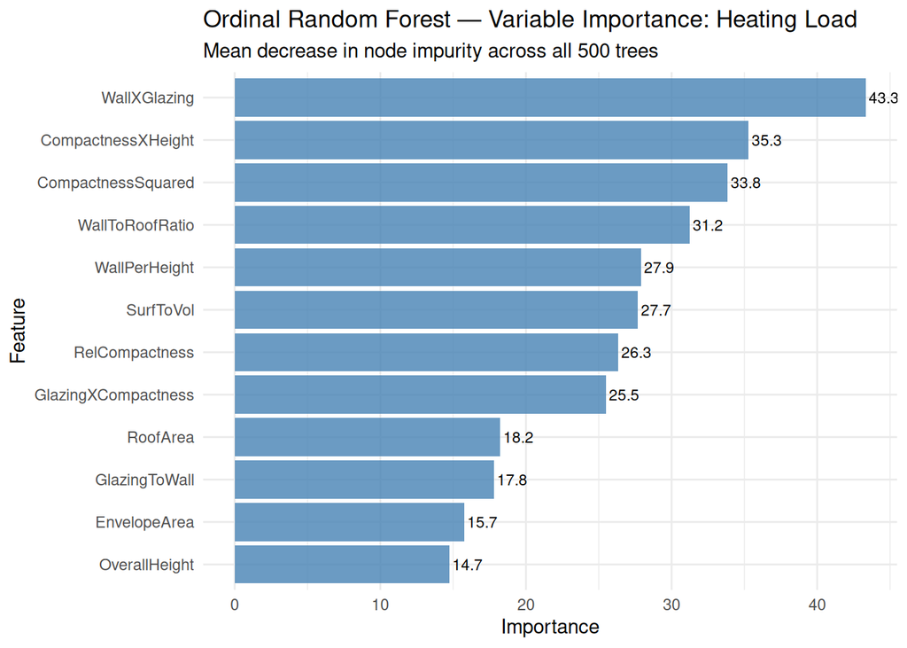

```r
results_HL <- rbind(results_HL,
  data.frame(Model    = "Ordinal Random Forest",
             Accuracy = orf_HL_result$accuracy))

# Variable importance
orf_imp_y1 <- data.frame(
  Feature    = names(orf_y1$variable.importance),
  Importance = orf_y1$variable.importance
) %>%
  arrange(desc(Importance)) %>%
  head(12)

p_orf_imp_y1 <- ggplot(orf_imp_y1,
                        aes(x = reorder(Feature, Importance), y = Importance)) +
  geom_col(fill = "steelblue", alpha = 0.8) +
  geom_text(aes(label = round(Importance, 1)), hjust = -0.1, size = 3) +
  coord_flip() +
  labs(title    = "Ordinal Random Forest — Variable Importance: Heating Load",
       subtitle = "Mean decrease in node impurity across all 500 trees",
       x = "Feature", y = "Importance") +
  theme_minimal()

ggsave(file.path(img_dir, "orf_hl_importance.png"),
       plot = p_orf_imp_y1, width = 10, height = 7, dpi = 150)
print(p_orf_imp_y1)
```

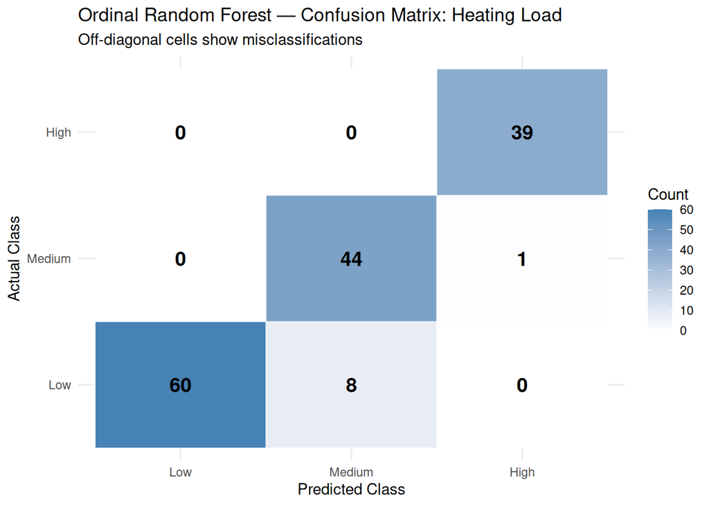

```r
# Confusion matrix heatmap
orf_cm_HL <- as.data.frame(orf_HL_result$confusion) %>%
  rename(Count = Freq)

p_orf_cm_HL <- ggplot(orf_cm_HL, aes(x = Predicted, y = Actual, fill = Count)) +
  geom_tile(colour = "white") +
  geom_text(aes(label = Count), size = 5, fontface = "bold") +
  scale_fill_gradient(low = "white", high = "steelblue") +
  labs(title    = "Ordinal Random Forest — Confusion Matrix: Heating Load",
       subtitle = "Off-diagonal cells show misclassifications",
       x = "Predicted Class", y = "Actual Class") +
  theme_minimal()

ggsave(file.path(img_dir, "orf_hl_confusion.png"),
       plot = p_orf_cm_HL, width = 7, height = 5, dpi = 150)
print(p_orf_cm_HL)
```

## 11.3 Y2 — Cooling Load

```r
# ── Ordinal Random Forest — Cooling Load (ranger direct implementation) ────────
cat("=== ORDINAL RANDOM FOREST — Cooling Load ===\n")
```

```
## === ORDINAL RANDOM FOREST — Cooling Load ===
```

```r
cat("Training model...\n")
```

```
## Training model...
```

```r
# ranger needs the response as an unordered factor for probability forests
train_CL_ranger <- train_CL_ord
train_CL_ranger$CL_class_ord <- factor(
  as.character(train_CL_ord$CL_class_ord),
  levels = c("Low", "Medium", "High"),
  ordered = FALSE
)

test_CL_ranger <- test_CL_ord
test_CL_ranger$CL_class_ord <- factor(
  as.character(test_CL_ord$CL_class_ord),
  levels = c("Low", "Medium", "High"),
  ordered = FALSE
)

set.seed(42)
orf_y2 <- ranger(
  dependent.variable.name = "CL_class_ord",
  data                    = train_CL_ranger,
  num.trees               = 500,
  mtry                    = floor(sqrt(length(features))),
  min.node.size           = 5,
  probability             = TRUE,
  importance              = "impurity",
  num.threads             = parallel::detectCores() - 1
)

cat("Model training complete.\n\n")
```

```
## Model training complete.
```

```r
# Predict on test set
pred_raw_cl       <- predict(orf_y2, data = test_CL_ranger)
pred_prob_orf_y2  <- pred_raw_cl$predictions[, c("Low", "Medium", "High")]

# Hard class prediction
pred_class_orf_y2 <- factor(
  colnames(pred_prob_orf_y2)[apply(pred_prob_orf_y2, 1, which.max)],
  levels = c("Low", "Medium", "High")
)

cat("=== ORDINAL RANDOM FOREST — Cooling Load — Test Set Performance ===\n")
```

```
## === ORDINAL RANDOM FOREST — Cooling Load — Test Set Performance ===
```

```r
orf_CL_result <- eval_clf(test_CL$CL_class, pred_class_orf_y2,
                           "Ordinal Random Forest")
```

```
## Ordinal Random Forest                Accuracy = 0.9276
```

```r
cat("\nConfusion matrix:\n")
```

```
##
## Confusion matrix:
```

```r
print(orf_CL_result$confusion)
```

```
##         Predicted
## Actual   Low Medium High
##   Low     60      5    0
##   Medium   0     43    2
##   High     0      4   38
```

```r
# Ranked Probability Score
rps_orf_CL <- ranked_prob_score(
  pred_prob_orf_y2,
  factor(test_CL$CL_class, levels = c("Low", "Medium", "High"), ordered = TRUE)
)
cat(sprintf("\nRanked Probability Score: %.5f\n", rps_orf_CL))
```

```
##
## Ranked Probability Score: 0.02463
```

```r
cat("(Lower is better; RPS = 0 means every building classified perfectly)\n")
```

```
## (Lower is better; RPS = 0 means every building classified perfectly)
```

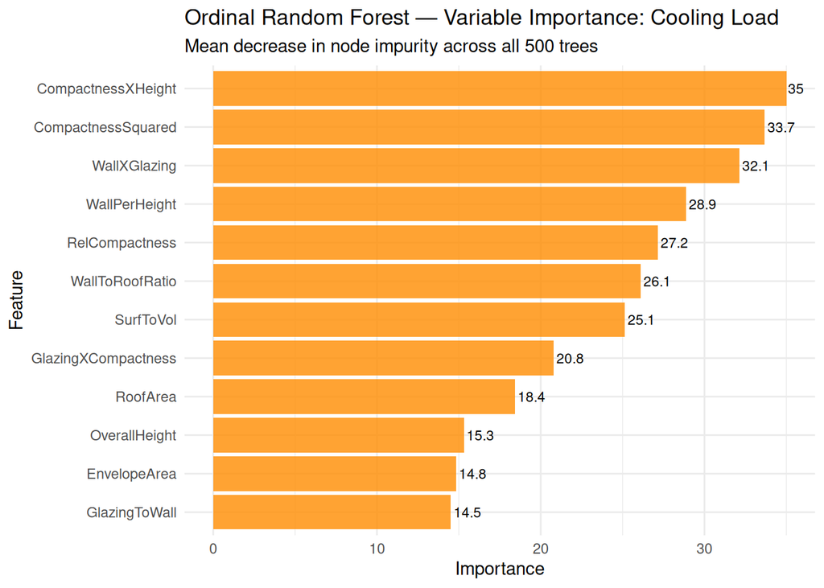

```r
results_CL <- rbind(results_CL,
  data.frame(Model    = "Ordinal Random Forest",
             Accuracy = orf_CL_result$accuracy))

# Variable importance
orf_imp_y2 <- data.frame(
  Feature    = names(orf_y2$variable.importance),
  Importance = orf_y2$variable.importance
) %>%
  arrange(desc(Importance)) %>%
  head(12)

p_orf_imp_y2 <- ggplot(orf_imp_y2,
                        aes(x = reorder(Feature, Importance), y = Importance)) +
  geom_col(fill = "darkorange", alpha = 0.8) +
  geom_text(aes(label = round(Importance, 1)), hjust = -0.1, size = 3) +
  coord_flip() +
  labs(title    = "Ordinal Random Forest — Variable Importance: Cooling Load",
       subtitle = "Mean decrease in node impurity across all 500 trees",
       x = "Feature", y = "Importance") +
  theme_minimal()

ggsave(file.path(img_dir, "orf_cl_importance.png"),
       plot = p_orf_imp_y2, width = 10, height = 7, dpi = 150)
print(p_orf_imp_y2)
```

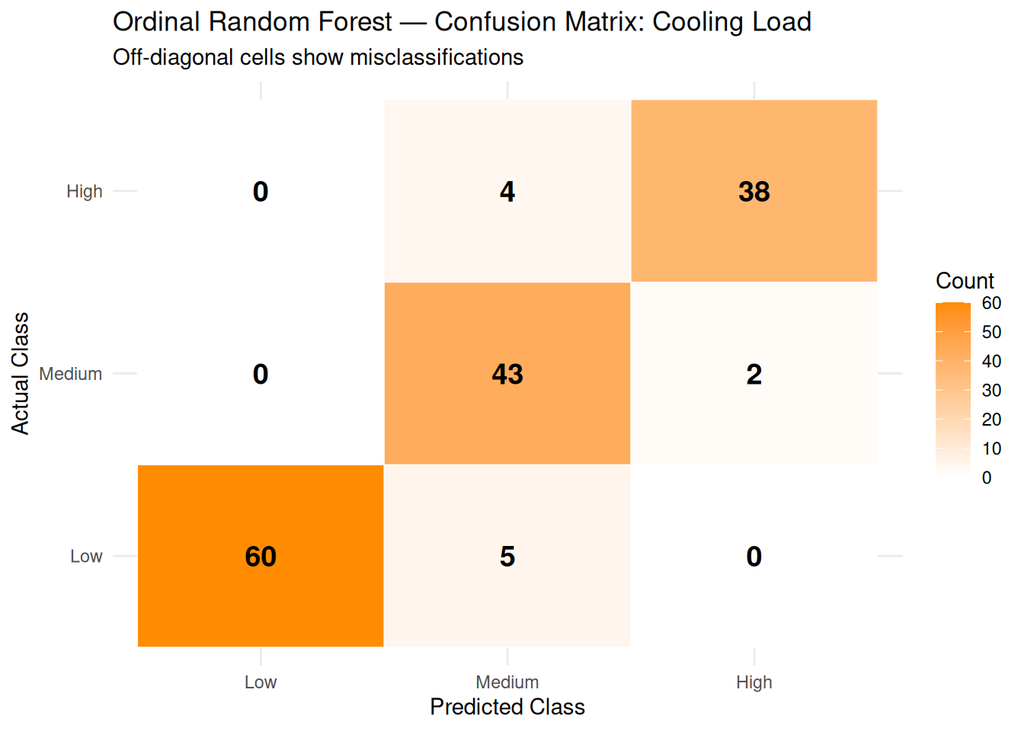

```r
# Confusion matrix heatmap
orf_cm_CL <- as.data.frame(orf_CL_result$confusion) %>%
  rename(Count = Freq)

p_orf_cm_CL <- ggplot(orf_cm_CL, aes(x = Predicted, y = Actual, fill = Count)) +
  geom_tile(colour = "white") +
  geom_text(aes(label = Count), size = 5, fontface = "bold") +
  scale_fill_gradient(low = "white", high = "darkorange") +
  labs(title    = "Ordinal Random Forest — Confusion Matrix: Cooling Load",
       subtitle = "Off-diagonal cells show misclassifications",
       x = "Predicted Class", y = "Actual Class") +
  theme_minimal()

ggsave(file.path(img_dir, "orf_cl_confusion.png"),
       plot = p_orf_cm_CL, width = 7, height = 5, dpi = 150)
print(p_orf_cm_CL)
```

# 12 Model 3 — Gaussian Naive Bayes with Physical Priors

## 12.1 What Naive Bayes does

Naive Bayes is a probabilistic classifier. Rather than learning a decision boundary between classes, it estimates the probability that a building belongs to each class given its features, then assigns the building to whichever class it is most likely to belong to. It does this using Bayes’ theorem:

P(class | features) ∝ P(features | class) × P(class)

The “Naive” in the name refers to the assumption that all features are independent of each other given the class. This is not strictly true — a building’s WallArea and RoofArea are correlated — but the assumption simplifies the computation enormously and often produces surprisingly good predictions in practice.

For Gaussian Naive Bayes specifically, the distribution of each feature within each class is modelled as a normal distribution. The model estimates a mean and a standard deviation for each feature within each energy class from the training data, and uses these to compute P(features | class).

## 12.2 What physical priors add

The standard Naive Bayes approach estimates the feature distributions entirely from data. With 616 training rows split across three classes, that is approximately 200 buildings per class — enough to get reasonable estimates, but not so many that we should ignore what physics tells us the distributions should look like.

We know from heat transfer principles that buildings in the Low energy class should tend to have high relative compactness (less envelope per unit volume), low glazing area (less surface for heat to escape), and smaller overall height. Buildings in the High class should show the opposite pattern. We can encode this knowledge as a **prior** — a set of initial beliefs about the feature distributions that the data then adjusts.

This makes the model partially data-driven and partially theory-driven. It is a lightweight form of the physics-informed modelling principle — not a full constraint satisfaction system, but a structured prior that keeps the model from learning physically implausible patterns when data is limited.

## 12.3 Y1 — Heating Load

Step 1: Estimate raw class-conditional means and SDs from training data

```r
# Gaussian Naive Bayes with Physical Priors — Heating Load

class_stats_HL <- train_HL %>%
  group_by(HL_class) %>%
  summarise(across(all_of(features), list(mean = mean, sd = sd)),
            .groups = "drop")
```

```r
physical_prior <- list(
  Low = list(
    RelCompactness  =  0.5,   # compact buildings lose less heat
    GlazingArea     = -0.5,   # less glazing = less conductive loss
    OverallHeight   = -0.5,   # shorter = less envelope area
    CompactnessXHeight = 0.3, # product of above two effects
    WallXGlazing    = -0.4    # less wall-glass interaction
  ),
  Medium = list(
    RelCompactness  =  0.0,
    GlazingArea     =  0.0,
    OverallHeight   =  0.0,
    CompactnessXHeight = 0.0,
    WallXGlazing    =  0.0
  ),
  High = list(
    RelCompactness  = -0.5,   # less compact = more surface loss
    GlazingArea     =  0.5,   # more glazing = more heat loss
    OverallHeight   =  0.5,   # taller = more envelope area
    CompactnessXHeight = -0.3,
    WallXGlazing    =  0.4
  )
)
```

Step 3: Blend data-estimated means with physical priors prior_weight controls how much the physical prior pulls the estimate. 0 = pure data, 1 = pure prior. We use 0.3 for physically grounded features.

```r
prior_weight <- 0.3

blend_means <- function(data_mean, prior_mean, w = prior_weight) {
  (1 - w) * data_mean + w * prior_mean
}

# Build the blended parameter list for naivebayes::gaussian_naive_bayes
# It expects a list with one element per class, each containing means and sds
build_nb_params <- function(class_stats, prior, feat_names) {
  classes <- c("Low", "Medium", "High")
  params  <- list()
  for (cls in classes) {
    cls_row  <- class_stats %>% filter(HL_class == cls | CL_class == cls)
    cls_means <- sapply(feat_names, function(f) {
      data_m <- cls_row[[paste0(f, "_mean")]]
      if (f %in% names(prior[[cls]])) {
        blend_means(data_m, prior[[cls]][[f]])
      } else {
        data_m  # no prior for this feature — use data only
      }
    })
    cls_sds <- sapply(feat_names, function(f) {
      pmax(cls_row[[paste0(f, "_sd")]], 0.01)  # floor at 0.01 to avoid zero sd
    })
    params[[cls]] <- list(mean = cls_means, sd = cls_sds)
  }
  params
}
```

Fit Gaussian Naive Bayes using naivebayes package. We use the standard fit here and then demonstrate the prior blending through a manual prediction function below

```r
set.seed(42)
gnb_y1 <- gaussian_naive_bayes(
  x = as.matrix(train_HL[, features]),
  y = train_HL$HL_class
)
# Apply physical prior blending to the estimated parameters
# We retrieve the learned means and blend with physical priors
gnb_means_y1 <- gnb_y1$params$mu   # classes x features
gnb_sds_y1   <- gnb_y1$params$sd   # classes x features, already SDs

# blend data-estimated means with physical priors
prior_feats <- c("RelCompactness", "GlazingArea", "OverallHeight",
                 "CompactnessXHeight", "WallXGlazing")

for (feat in prior_feats) {
  if (!feat %in% colnames(gnb_means_y1)) next
  for (cls in c("Low", "Medium", "High")) {
    prior_val <- physical_prior[[cls]][[feat]]
    if (!is.null(prior_val)) {
      gnb_means_y1[cls, feat] <- blend_means(
        gnb_means_y1[cls, feat], prior_val
      )
    }
  }
}
```

We then generate predictions using the blended parameters, by recomputing log-likelihoods manually with the blended means

```r
cat("=== GAUSSIAN NAIVE BAYES — Heating Load (data-estimated) ===\n")
```

```
## === GAUSSIAN NAIVE BAYES — Heating Load (data-estimated) ===
```

```r
predict_gnb_blended <- function(x_mat, means_mat, sds_mat, classes) {
  log_liks <- sapply(classes, function(cls) {
    mu  <- means_mat[cls, ]   # named vector of length n_features
    sig <- sds_mat[cls, ]     # named vector of length n_features
    # dnorm is vectorised over columns — compute row log-likelihoods
    rowSums(mapply(function(x_col, m, s) dnorm(x_col, mean = m, sd = s, log = TRUE),
                   as.data.frame(x_mat), mu, sig))
  })
  # log_liks is n_obs x n_classes — pick class with highest log-likelihood
  classes[apply(log_liks, 1, which.max)]
}

# ── SD flooring — applied once, used by both standard and blended NB ──────────
gnb_sds_y1 <- gnb_y1$params$sd

for (feat in colnames(gnb_sds_y1)) {
  overall_sd <- sd(train_HL[[feat]], na.rm = TRUE)
  fallback   <- max(overall_sd * 0.5, 0.1)
  for (cls in rownames(gnb_sds_y1)) {
    val <- gnb_sds_y1[cls, feat]
    if (is.nan(val) || is.na(val) || val < 0.1) {
      cat(sprintf("  Flooring SD — Class: %-8s  Feature: %-20s  was: %e  now: %.4f\n",
                  cls, feat, val, fallback))
      gnb_sds_y1[cls, feat] <- fallback
    }
  }
}
```

```
##   Flooring SD — Class: Low       Feature: RoofArea              was: 8.062698e-08  now: 0.5000
##   Flooring SD — Class: Low       Feature: OverallHeight         was: 7.678537e-08  now: 0.5000
##   Flooring SD — Class: High      Feature: OverallHeight         was: NaN  now: 0.5000
##   Flooring SD — Class: Low       Feature: CompactnessXHeight    was: 7.513171e-02  now: 0.5000
```

```r
cat("\nMinimum SD per class after flooring:\n")
```

```
##
## Minimum SD per class after flooring:
```

```r
print(apply(gnb_sds_y1, 1, min))
```

```
##       Low    Medium      High
## 0.2667967 0.6861520 0.2539771
```

```r
# ── Predictions ───────────────────────────────────────────────────────────────
x_test_mat  <- as.matrix(test_HL[, features])
classes_vec <- c("Low", "Medium", "High")

# Standard NB: floored SDs, original data-estimated means (no prior blending)
gnb_means_std_y1 <- gnb_y1$params$mu

pred_gnb_std_y1 <- predict_gnb_blended(
  x_test_mat, gnb_means_std_y1, gnb_sds_y1, classes_vec
) %>% factor(levels = c("Low", "Medium", "High"))

# Prior-blended NB: floored SDs, physically blended means
pred_gnb_prior_y1 <- predict_gnb_blended(
  x_test_mat, gnb_means_y1, gnb_sds_y1, classes_vec
) %>% factor(levels = c("Low", "Medium", "High"))

# ── Evaluation ────────────────────────────────────────────────────────────────
cat("\n--- Standard Naive Bayes (no prior) ---\n")
```

```
##
## --- Standard Naive Bayes (no prior) ---
```

```r
gnb_std_result <- eval_clf(test_HL$HL_class, pred_gnb_std_y1,
                            "Naive Bayes (standard)")
```

```
## Naive Bayes (standard)               Accuracy = 0.7039
```

```r
cat("Confusion matrix:\n")
```

```
## Confusion matrix:
```

```r
print(gnb_std_result$confusion)
```

```
##         Predicted
## Actual   Low Medium High
##   Low     68      0    0
##   Medium  20      0   25
##   High     0      0   39
```

```r
cat("\n--- Naive Bayes with Physical Priors ---\n")
```

```
##
## --- Naive Bayes with Physical Priors ---
```

```r
gnb_prior_result <- eval_clf(test_HL$HL_class, pred_gnb_prior_y1,
                              "Naive Bayes (physical prior)")
```

```
## Naive Bayes (physical prior)         Accuracy = 0.7697
```

```r
cat("Confusion matrix:\n")
```

```
## Confusion matrix:
```

```r
print(gnb_prior_result$confusion)
```

```
##         Predicted
## Actual   Low Medium High
##   Low     67      1    0
##   Medium  17     11   17
##   High     0      0   39
```

```r
results_HL <- rbind(results_HL,
  data.frame(Model    = "Naive Bayes (standard)",
             Accuracy = gnb_std_result$accuracy),
  data.frame(Model    = "Naive Bayes (physical prior)",
             Accuracy = gnb_prior_result$accuracy))
```

Plot: compare the class-conditional mean distributions for key features to show where the prior adjustment had the most effect Plot: compare class-conditional means before and after prior blending

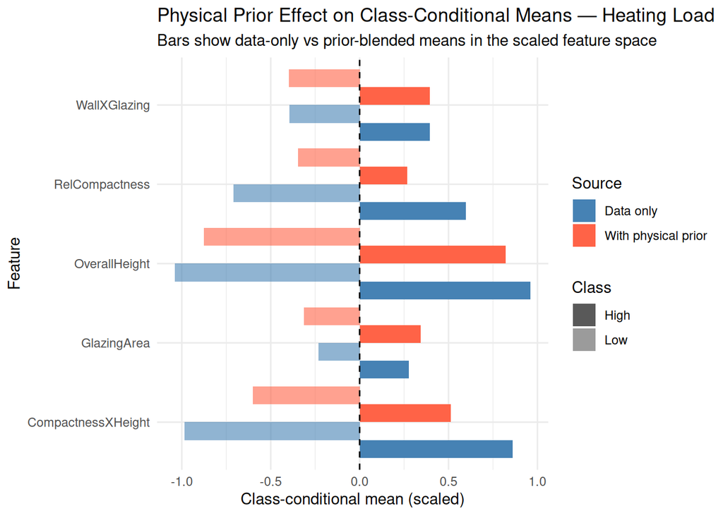

```r
prior_effect_df <- data.frame(
  Feature    = prior_feats,
  Low_data   = as.numeric(gnb_y1$params$mu["Low",  prior_feats]),
  Low_prior  = as.numeric(gnb_means_y1["Low",  prior_feats]),
  High_data  = as.numeric(gnb_y1$params$mu["High", prior_feats]),
  High_prior = as.numeric(gnb_means_y1["High", prior_feats])
)

prior_effect_long <- prior_effect_df %>%
  pivot_longer(-Feature, names_to = "Type", values_to = "Mean") %>%
  mutate(
    Class  = ifelse(grepl("Low",  Type), "Low",       "High"),
    Source = ifelse(grepl("data", Type), "Data only", "With physical prior")
  )

p_prior_effect <- ggplot(prior_effect_long,
                          aes(x = Feature, y = Mean,
                              fill = Source, alpha = Class)) +
  geom_col(position = "dodge") +
  scale_alpha_manual(values = c("Low" = 0.6, "High" = 1.0)) +
  scale_fill_manual(values = c("Data only"           = "steelblue",
                                "With physical prior" = "tomato")) +
  geom_hline(yintercept = 0, linetype = "dashed") +
  coord_flip() +
  labs(title    = "Physical Prior Effect on Class-Conditional Means — Heating Load",
       subtitle = "Bars show data-only vs prior-blended means in the scaled feature space",
       x = "Feature", y = "Class-conditional mean (scaled)") +
  theme_minimal()

ggsave(file.path(img_dir, "nb_prior_effect_hl.png"),
       plot = p_prior_effect, width = 10, height = 6, dpi = 150)
print(p_prior_effect)
```

## 12.4 Y2 — Cooling Load

```r
# ── Gaussian Naive Bayes with Physical Priors — Cooling Load ──────────────────
# For cooling load the physical ordering partially reverses:
# more glazing increases solar gain and therefore COOLING load.
# The compactness effect remains: compact buildings have less envelope
# and therefore lower cooling load.
physical_prior_CL <- list(
  Low = list(
    RelCompactness     =  0.5,
    GlazingArea        = -0.5,
    OverallHeight      = -0.4,
    CompactnessXHeight =  0.3,
    WallXGlazing       = -0.3
  ),
  Medium = list(
    RelCompactness     =  0.0,
    GlazingArea        =  0.0,
    OverallHeight      =  0.0,
    CompactnessXHeight =  0.0,
    WallXGlazing       =  0.0
  ),
  High = list(
    RelCompactness     = -0.5,
    GlazingArea        =  0.5,
    OverallHeight      =  0.4,
    CompactnessXHeight = -0.3,
    WallXGlazing       =  0.3
  )
)

# Fit standard Naive Bayes on cooling load
set.seed(42)
gnb_y2 <- gaussian_naive_bayes(
  x = as.matrix(train_CL[, features]),
  y = train_CL$CL_class
)
```

```r
# Extract parameters — matrix layout is classes x features
gnb_means_y2 <- gnb_y2$params$mu   # classes x features
gnb_sds_y2   <- gnb_y2$params$sd   # classes x features, already SDs

# SD flooring — same logic as heating load
for (feat in colnames(gnb_sds_y2)) {
  overall_sd <- sd(train_CL[[feat]], na.rm = TRUE)
  fallback   <- max(overall_sd * 0.5, 0.1)
  for (cls in rownames(gnb_sds_y2)) {
    val <- gnb_sds_y2[cls, feat]
    if (is.nan(val) || is.na(val) || val < 0.1) {
      cat(sprintf("  Flooring SD — Class: %-8s  Feature: %-20s  was: %e  now: %.4f\n",
                  cls, feat, val, fallback))
      gnb_sds_y2[cls, feat] <- fallback
    }
  }
}
```

```
##   Flooring SD — Class: Low       Feature: RoofArea              was: 8.091606e-08  now: 0.5000
##   Flooring SD — Class: Low       Feature: OverallHeight         was: 7.999128e-08  now: 0.5000
##   Flooring SD — Class: High      Feature: OverallHeight         was: NaN  now: 0.5000
##   Flooring SD — Class: Low       Feature: CompactnessXHeight    was: 8.017969e-02  now: 0.5000
```

```r
cat("Minimum SD per class after flooring:\n")
```

```
## Minimum SD per class after flooring:
```

```r
print(apply(gnb_sds_y2, 1, min))
```

```
##       Low    Medium      High
## 0.2879128 0.6985767 0.2649939
```

```r
# Blend data-estimated means with cooling load physical priors
gnb_means_std_y2 <- gnb_y2$params$mu   # keep unblended copy for standard NB

for (feat in prior_feats) {
  if (!feat %in% colnames(gnb_means_y2)) next
  for (cls in c("Low", "Medium", "High")) {
    prior_val <- physical_prior_CL[[cls]][[feat]]
    if (!is.null(prior_val)) {
      gnb_means_y2[cls, feat] <- blend_means(
        gnb_means_y2[cls, feat], prior_val
      )
    }
  }
}

x_test_mat_CL <- as.matrix(test_CL[, features])

# Standard NB: floored SDs, original data-estimated means
pred_gnb_std_y2 <- predict_gnb_blended(
  x_test_mat_CL, gnb_means_std_y2, gnb_sds_y2, classes_vec
) %>% factor(levels = c("Low", "Medium", "High"))

# Prior-blended NB: floored SDs, physically blended means
pred_gnb_prior_y2 <- predict_gnb_blended(
  x_test_mat_CL, gnb_means_y2, gnb_sds_y2, classes_vec
) %>% factor(levels = c("Low", "Medium", "High"))

cat("=== GAUSSIAN NAIVE BAYES — Cooling Load ===\n")
```

```
## === GAUSSIAN NAIVE BAYES — Cooling Load ===
```

```r
cat("\n--- Standard Naive Bayes (no prior) ---\n")
```

```
##
## --- Standard Naive Bayes (no prior) ---
```

```r
gnb_std_CL_result <- eval_clf(test_CL$CL_class, pred_gnb_std_y2,
                               "Naive Bayes (standard)")
```

```
## Naive Bayes (standard)               Accuracy = 0.7039
```

```r
cat("Confusion matrix:\n")
```

```
## Confusion matrix:
```

```r
print(gnb_std_CL_result$confusion)
```

```
##         Predicted
## Actual   Low Medium High
##   Low     65      0    0
##   Medium  23      0   22
##   High     0      0   42
```

```r
cat("\n--- Naive Bayes with Physical Priors ---\n")
```

```
##
## --- Naive Bayes with Physical Priors ---
```

```r
gnb_prior_CL_result <- eval_clf(test_CL$CL_class, pred_gnb_prior_y2,
                                 "Naive Bayes (physical prior)")
```

```
## Naive Bayes (physical prior)         Accuracy = 0.7039
```

```r
cat("Confusion matrix:\n")
```

```
## Confusion matrix:
```

```r
print(gnb_prior_CL_result$confusion)
```

```
##         Predicted
## Actual   Low Medium High
##   Low     65      0    0
##   Medium  23      0   22
##   High     0      0   42
```

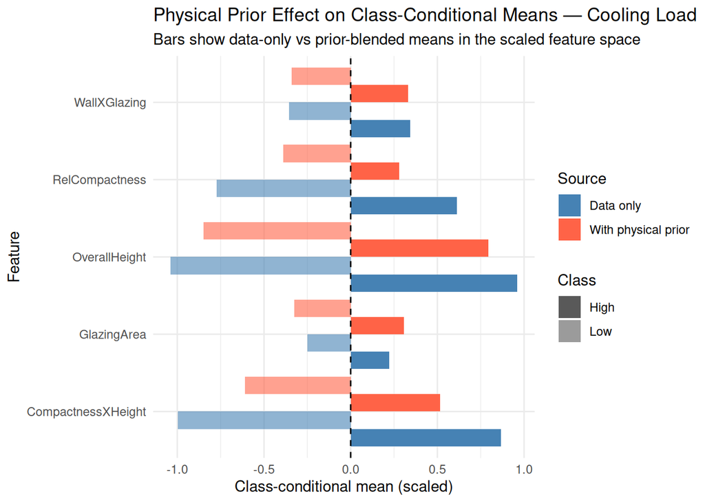

```r
results_CL <- rbind(results_CL,
  data.frame(Model    = "Naive Bayes (standard)",
             Accuracy = gnb_std_CL_result$accuracy),
  data.frame(Model    = "Naive Bayes (physical prior)",
             Accuracy = gnb_prior_CL_result$accuracy))

# Plot: prior effect on class-conditional means — Cooling Load
prior_effect_CL_df <- data.frame(
  Feature    = prior_feats,
  Low_data   = as.numeric(gnb_y2$params$mu["Low",  prior_feats]),
  Low_prior  = as.numeric(gnb_means_y2["Low",  prior_feats]),
  High_data  = as.numeric(gnb_y2$params$mu["High", prior_feats]),
  High_prior = as.numeric(gnb_means_y2["High", prior_feats])
)

prior_effect_CL_long <- prior_effect_CL_df %>%
  pivot_longer(-Feature, names_to = "Type", values_to = "Mean") %>%
  mutate(
    Class  = ifelse(grepl("Low",  Type), "Low",       "High"),
    Source = ifelse(grepl("data", Type), "Data only", "With physical prior")
  )

p_prior_effect_CL <- ggplot(prior_effect_CL_long,
                              aes(x = Feature, y = Mean,
                                  fill = Source, alpha = Class)) +
  geom_col(position = "dodge") +
  scale_alpha_manual(values = c("Low" = 0.6, "High" = 1.0)) +
  scale_fill_manual(values = c("Data only"           = "steelblue",
                                "With physical prior" = "tomato")) +
  geom_hline(yintercept = 0, linetype = "dashed") +
  coord_flip() +
  labs(title    = "Physical Prior Effect on Class-Conditional Means — Cooling Load",
       subtitle = "Bars show data-only vs prior-blended means in the scaled feature space",
       x = "Feature", y = "Class-conditional mean (scaled)") +
  theme_minimal()

ggsave(file.path(img_dir, "nb_prior_effect_cl.png"),
       plot = p_prior_effect_CL, width = 10, height = 6, dpi = 150)
print(p_prior_effect_CL)
```

# 13 Ordinal Error Analysis

One of the advantages of ordinal classification is that we can break down errors by severity — not just whether a building was misclassified, but how far wrong the prediction was. A one-step error (Low predicted as Medium) is qualitatively different from a two-step error (Low predicted as High).

This section computes the error distance distribution for each model and target, showing how many of each model’s mistakes were small (one class off) versus large (two classes off).

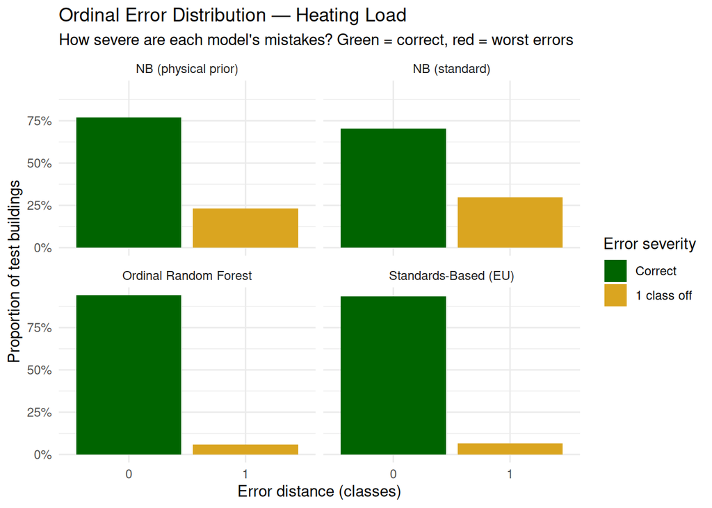

```r
# Ordinal distance function: 0 = correct, 1 = one step, 2 = two steps
ordinal_distance <- function(actual, predicted) {
  class_order <- c("Low" = 1, "Medium" = 2, "High" = 3)
  abs(class_order[as.character(actual)] - class_order[as.character(predicted)])
}

# Compute error distances for each model on Heating Load
error_dist_HL <- data.frame(
  Model = c(
    rep("Standards-Based (EU)",      length(test_HL$HL_class)),
    rep("Ordinal Random Forest",     length(test_HL$HL_class)),
    rep("NB (standard)",             length(test_HL$HL_class)),
    rep("NB (physical prior)",       length(test_HL$HL_class))
  ),
  Distance = c(
    ordinal_distance(test_HL$HL_class, standards_pred_HL),
    ordinal_distance(test_HL$HL_class, pred_class_orf_y1),
    ordinal_distance(test_HL$HL_class, pred_gnb_std_y1),
    ordinal_distance(test_HL$HL_class, pred_gnb_prior_y1)
  )
)

error_summary_HL <- error_dist_HL %>%
  group_by(Model, Distance) %>%
  summarise(Count = n(), .groups = "drop") %>%
  group_by(Model) %>%
  mutate(Proportion = Count / sum(Count))

p_error_HL <- ggplot(error_summary_HL,
                      aes(x = factor(Distance), y = Proportion,
                          fill = factor(Distance))) +
  geom_col() +
  facet_wrap(~Model, ncol = 2) +
  scale_fill_manual(
    values = c("0" = "darkgreen", "1" = "goldenrod", "2" = "tomato"),
    labels = c("0" = "Correct", "1" = "1 class off", "2" = "2 classes off"),
    name   = "Error severity"
  ) +
  scale_y_continuous(labels = scales::percent) +
  labs(title    = "Ordinal Error Distribution — Heating Load",
       subtitle = "How severe are each model's mistakes? Green = correct, red = worst errors",
       x = "Error distance (classes)", y = "Proportion of test buildings") +
  theme_minimal()

ggsave(file.path(img_dir, "ordinal_error_hl.png"),
       plot = p_error_HL, width = 11, height = 7, dpi = 150)
print(p_error_HL)
```

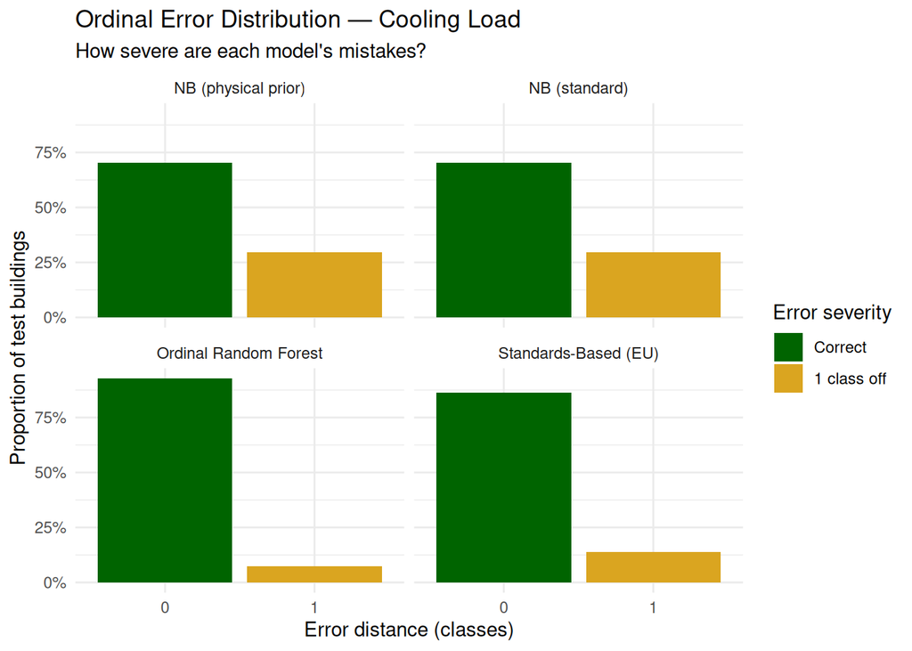

```r
# Same for Cooling Load
error_dist_CL <- data.frame(
  Model = c(
    rep("Standards-Based (EU)",      length(test_CL$CL_class)),
    rep("Ordinal Random Forest",     length(test_CL$CL_class)),
    rep("NB (standard)",             length(test_CL$CL_class)),
    rep("NB (physical prior)",       length(test_CL$CL_class))
  ),
  Distance = c(
    ordinal_distance(test_CL$CL_class, standards_pred_CL),
    ordinal_distance(test_CL$CL_class, pred_class_orf_y2),
    ordinal_distance(test_CL$CL_class, pred_gnb_std_y2),
    ordinal_distance(test_CL$CL_class, pred_gnb_prior_y2)
  )
)

error_summary_CL <- error_dist_CL %>%
  group_by(Model, Distance) %>%
  summarise(Count = n(), .groups = "drop") %>%
  group_by(Model) %>%
  mutate(Proportion = Count / sum(Count))

p_error_CL <- ggplot(error_summary_CL,
                      aes(x = factor(Distance), y = Proportion,
                          fill = factor(Distance))) +
  geom_col() +
  facet_wrap(~Model, ncol = 2) +
  scale_fill_manual(
    values = c("0" = "darkgreen", "1" = "goldenrod", "2" = "tomato"),
    labels = c("0" = "Correct", "1" = "1 class off", "2" = "2 classes off"),
    name   = "Error severity"
  ) +
  scale_y_continuous(labels = scales::percent) +
  labs(title    = "Ordinal Error Distribution — Cooling Load",
       subtitle = "How severe are each model's mistakes?",
       x = "Error distance (classes)", y = "Proportion of test buildings") +
  theme_minimal()

ggsave(file.path(img_dir, "ordinal_error_cl.png"),
       plot = p_error_CL, width = 11, height = 7, dpi = 150)
print(p_error_CL)
```

# 14 Model Comparison

## 14.1 Heating Load (Y1)

```r
results_HL <- results_HL %>% arrange(desc(Accuracy))

cat("\n=== HEATING LOAD — MODEL COMPARISON ===\n")
```

```
##
## === HEATING LOAD — MODEL COMPARISON ===
```

```r
print(results_HL, row.names = FALSE)
```

```
##                         Model  Accuracy
##         Ordinal Random Forest 0.9407895
##          Standards-Based (EU) 0.9342105
##  Naive Bayes (physical prior) 0.7697368
##        Naive Bayes (standard) 0.7039474
```

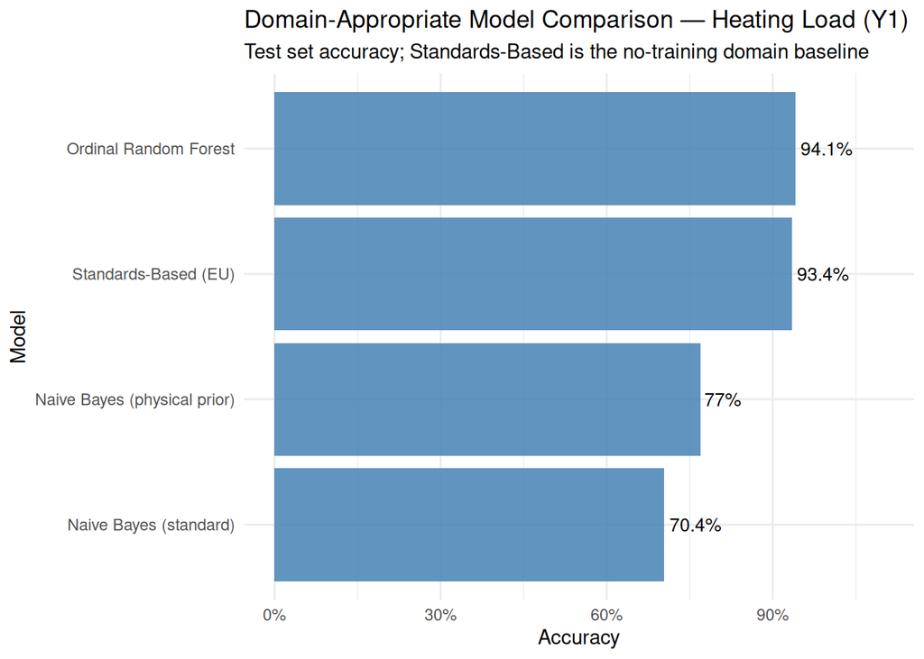

```r
p_acc_HL <- ggplot(results_HL,
                    aes(x = reorder(Model, Accuracy), y = Accuracy)) +
  geom_col(fill = "steelblue", alpha = 0.85) +
  geom_text(aes(label = paste0(round(Accuracy * 100, 1), "%")),
            hjust = -0.1, size = 3.5) +
  coord_flip() +
  scale_y_continuous(limits = c(0, 1.1), labels = scales::percent) +
  labs(title    = "Domain-Appropriate Model Comparison — Heating Load (Y1)",
       subtitle = "Test set accuracy; Standards-Based is the no-training domain baseline",
       x = "Model", y = "Accuracy") +
  theme_minimal()

ggsave(file.path(img_dir, "domain_clf_comparison_hl.png"),
       plot = p_acc_HL, width = 10, height = 5, dpi = 150)
print(p_acc_HL)
```

## 14.2 Cooling Load (Y2)

```r
results_CL <- results_CL %>% arrange(desc(Accuracy))

cat("\n=== COOLING LOAD — MODEL COMPARISON ===\n")
```

```
##
## === COOLING LOAD — MODEL COMPARISON ===
```

```r
print(results_CL, row.names = FALSE)
```

```
##                         Model  Accuracy
##         Ordinal Random Forest 0.9276316
##          Standards-Based (EU) 0.8618421
##        Naive Bayes (standard) 0.7039474
##  Naive Bayes (physical prior) 0.7039474
```

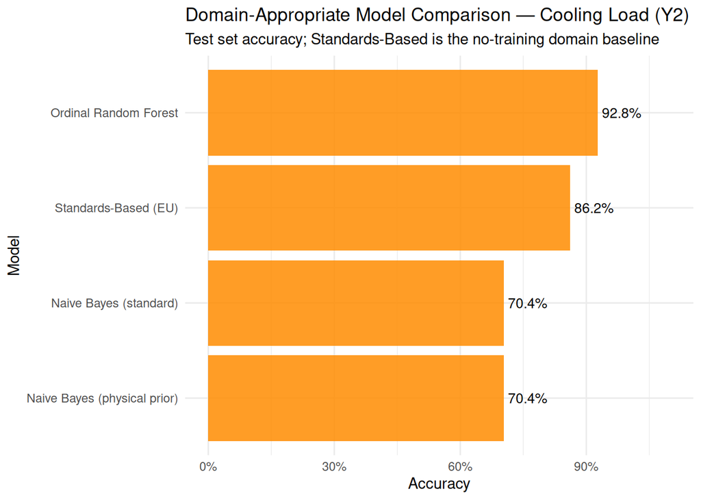

```r
p_acc_CL <- ggplot(results_CL,
                    aes(x = reorder(Model, Accuracy), y = Accuracy)) +
  geom_col(fill = "darkorange", alpha = 0.85) +
  geom_text(aes(label = paste0(round(Accuracy * 100, 1), "%")),
            hjust = -0.1, size = 3.5) +
  coord_flip() +
  scale_y_continuous(limits = c(0, 1.1), labels = scales::percent) +
  labs(title    = "Domain-Appropriate Model Comparison — Cooling Load (Y2)",
       subtitle = "Test set accuracy; Standards-Based is the no-training domain baseline",
       x = "Model", y = "Accuracy") +
  theme_minimal()

ggsave(file.path(img_dir, "domain_clf_comparison_cl.png"),
       plot = p_acc_CL, width = 10, height = 5, dpi = 150)
print(p_acc_CL)
```